# ChemmineR: introductory session

### Clustering

Duplicate compounds can be identified via the `cmp.duplicated` function.

```r
## Vector format
cmp.duplicated(apset, type=1)
```

```
##  [1] FALSE FALSE FALSE FALSE FALSE FALSE FALSE FALSE FALSE FALSE FALSE
## [12] FALSE FALSE FALSE FALSE FALSE FALSE FALSE FALSE FALSE FALSE FALSE
## [23] FALSE FALSE FALSE FALSE FALSE FALSE FALSE FALSE FALSE FALSE FALSE
## [34] FALSE FALSE FALSE FALSE FALSE FALSE FALSE FALSE FALSE FALSE FALSE
## [45] FALSE FALSE FALSE FALSE FALSE FALSE FALSE FALSE FALSE FALSE  TRUE
## [56] FALSE  TRUE FALSE  TRUE FALSE  TRUE FALSE FALSE FALSE FALSE FALSE
## [67] FALSE FALSE FALSE FALSE FALSE FALSE FALSE FALSE FALSE FALSE FALSE
## [78] FALSE FALSE FALSE FALSE FALSE FALSE FALSE FALSE FALSE
```

```r
## Data frame format
head( cmp.duplicated(apset, type=2), 25)
```

```
##      ids CLSZ_100 CLID_100
## 1  CMP86        1        1
## 2  CMP80        1        2
## 3  CMP60        2        3
## 4  CMP61        2        3
## 5  CMP66        1        4
## 6  CMP21        1        5
## 7  CMP20        1        6
## 8  CMP52        1        7
## 9  CMP15        1        8
## 10 CMP30        1        9
## 11  CMP6        1       10
## 12 CMP11        1       11
## 13  CMP9        1       12
## 14 CMP28        1       13
## 15  CMP4        1       14
## 16 CMP32        1       15
## 17 CMP48        1       16
## 18 CMP49        1       17
## 19 CMP18        1       18
## 20 CMP56        2       19
## 21 CMP57        2       19
## 22 CMP42        1       20
## 23  CMP7        1       21
## 24 CMP85        1       22
## 25 CMP26        1       23
```

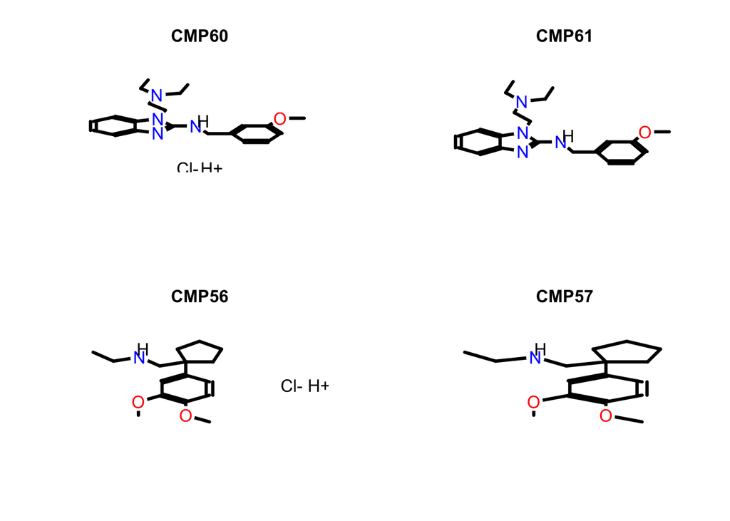

```r
## Plot the pairs of identical compounds (60 & 61, 56 & 57)
plot(sdfset[c("CMP60", "CMP61", "CMP56", "CMP57")], print=FALSE)
```

The `cmp.cluster` function placs compounds into “similarity bins”. Compounds are placed in the same bin if their similraity score exceeds a threshold.

```r
clusters <- cmp.cluster(db=apset, cutoff = c(0.7, 0.8, 0.9), quiet = TRUE)
```

```
##
## sorting result...
```

```r
clusters[1:12,]
```

```
##      ids CLSZ_0.7 CLID_0.7 CLSZ_0.8 CLID_0.8 CLSZ_0.9 CLID_0.9
## 48 CMP48        2       48        2       48        2       48
## 49 CMP49        2       48        2       48        2       48
## 54 CMP54        2       54        2       54        2       54
## 55 CMP55        2       54        2       54        2       54
## 56 CMP56        2       56        2       56        2       56
## 57 CMP57        2       56        2       56        2       56
## 58 CMP58        2       58        2       58        2       58
## 59 CMP59        2       58        2       58        2       58
## 60 CMP60        2       60        2       60        2       60
## 61 CMP61        2       60        2       60        2       60
## 1   CMP1        1        1        1        1        1        1
## 2   CMP2        1        2        1        2        1        2
```

```r
## Are CMP48 adn CMP49 identical?
cmp.duplicated(apset[c(48,49)], type=1)
```

```
## [1] FALSE FALSE
```

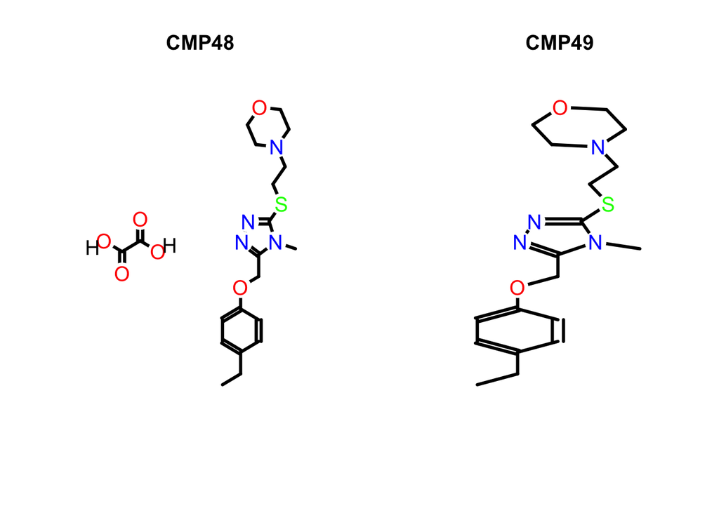

```r
## What do they look like?
plot(sdfset[c("CMP48", "CMP49")], griddim=c(1,2), print=FALSE)
```

### Additional types of clustering

We can compute distances between the atom pair representations, and use these for hierarchical clustering. The way the `cmp.cluster` function works means that the distances have to be saved as an RData object, and then read back in…

```r
## Peform clustering, and save the distamce data as an RData object
dummy <- cmp.cluster(db=apset, cutoff=0, save.distances="distmat.rda", quiet=TRUE)
```

```
##
## sorting result...
```

Now load the distances back into R:

```r
load("distmat.rda")
```

These can be used with standard R clustering algorithms (e.g., hierarchical clustering):

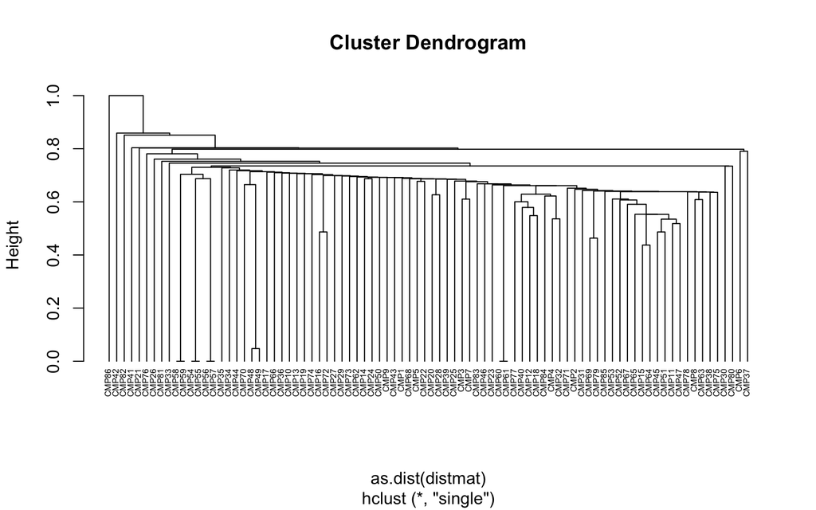

```r
## Hierarchical clustering with hclust (convert cmp.cluster distances to an
## R "dist" object, and use hclust to perform hierarchical clustering:
hc <- hclust(as.dist(distmat), method="single")

## Add compound labels to hc object
hc[["labels"]] <- cid(apset)

## Reset the plotting window for a single plot
par(mfrow=c(1,1))

## Plot the output as a dendrogram
plot(hc, hang=-1, cex=0.5)
```

And, of course, with hierarchical clustering comes heatmaps…

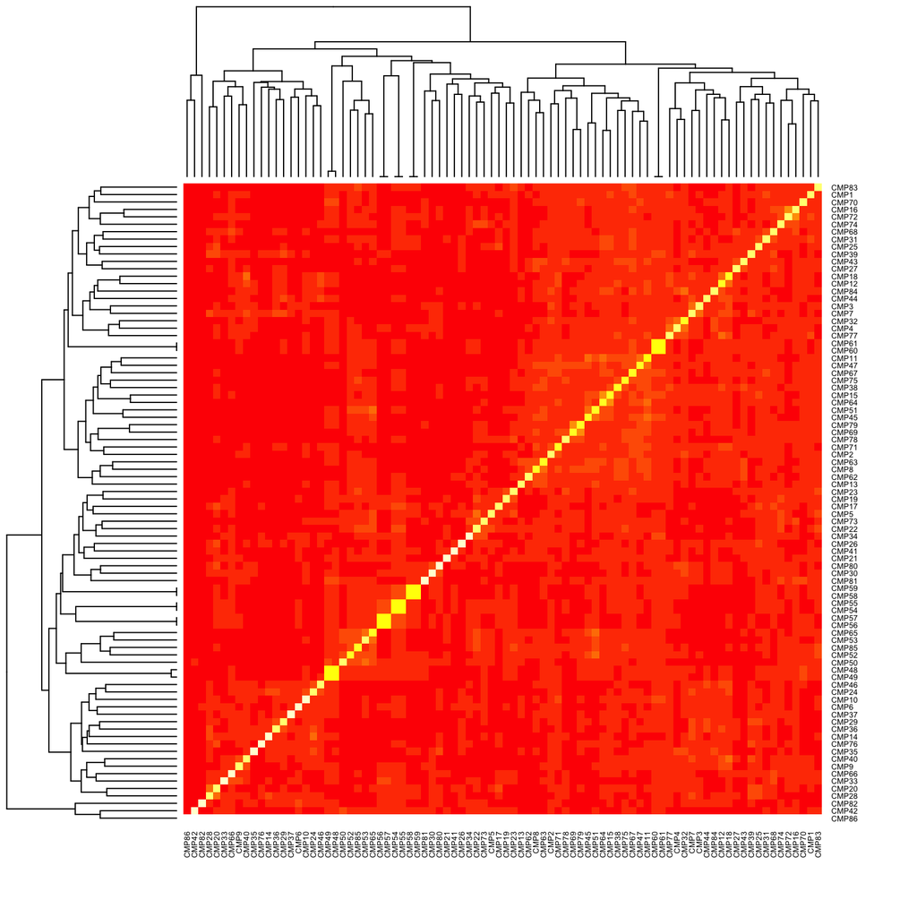

```r
heatmap(1-distmat, labCol = cid(apset), labRow = cid(apset), cexRow = 0.5, cexCol = 0.5)
```